# CRISP Day 8 2026: Graphing with ggplot2

In today’s lesson, we will learn the basics of graphing with the `ggplot2` package and using ChatGPT as a tool to help conduct data analysis.

```r
library(dplyr)

# read in data
my_data <- read.csv("crisp-2024-sample100.csv")

# convert some columns to factors
my_data <- my_data %>%
  mutate(tx = factor(tx, labels = c("BUP-NX", "XR-NTX")),
         sex = factor(sex, labels = c("Male", "Female")),
         smoke100 = factor(smoke100, labels = c("Non-smoker", "Smoker")))
```

# Graphing with ggplot2

`ggplot2` is a very popular plotting package in R. Base R contains default plotting functions (with the `plot()` function), but these are often not intuitive and difficult to customize. `ggplot2` provides a more intuitive and customizable interface for graphing data. We start by reading in the library.

```r
library(ggplot2)
```

## ggplot2 syntax

To create a `ggplot2` graph, you start off with the `ggplot()` function. Within the `ggplot()` function, you specify the dataset and which columns you want to put in each axis in an aesthetic layer `aes(x = x_var, y = y_var)`.

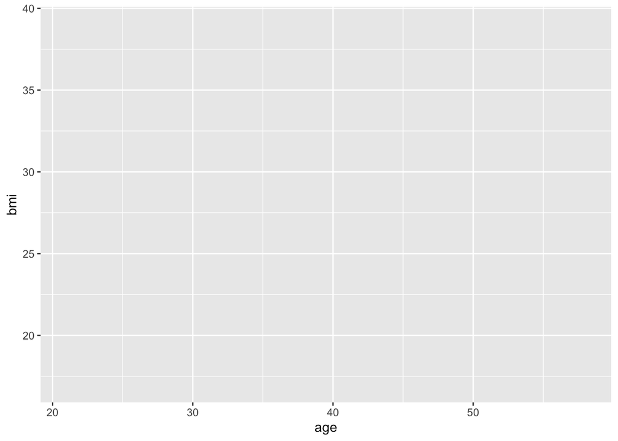

```r
ggplot(data = my_data, aes(x = age, y = bmi))
```

In our `aes()` call, we want `age` to be on our x-axis, and `bmi` to be on our y-axis. Note that this code plots an empty graph. That is because we haven’t specified what objects we want to include in our plot. To do this, we use `+` to add geometric features to our plot.

## Scatter plots

If we want to create a scatter plot, we can add `+ geom_point()` to our code. For example:

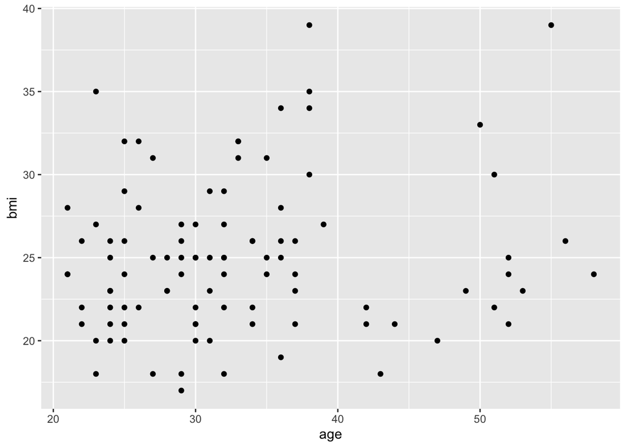

```r
ggplot(data = my_data, aes(x = age, y = bmi)) +
  geom_point()
```

Now we have successfully graphed a scatter plot! Let’s now make some customizations.

Suppose that we want the colors of the points to correspond to the treatment arm. We can add a `color = tx` argument within the `aes()` call:

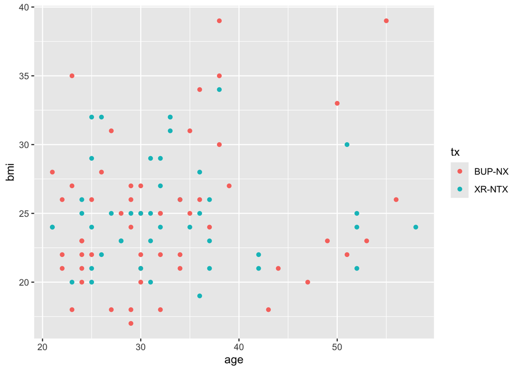

```r
ggplot(data = my_data, aes(x = age, y = bmi, color = tx)) +
  geom_point()
```

We can also change the “look” of our plot. For example, if we add `+ xlim(0, 60)` and `+ ylim(0,40)`, we can change the x and y axis ranges of our plot to 0-60 and 0-40, respectively.

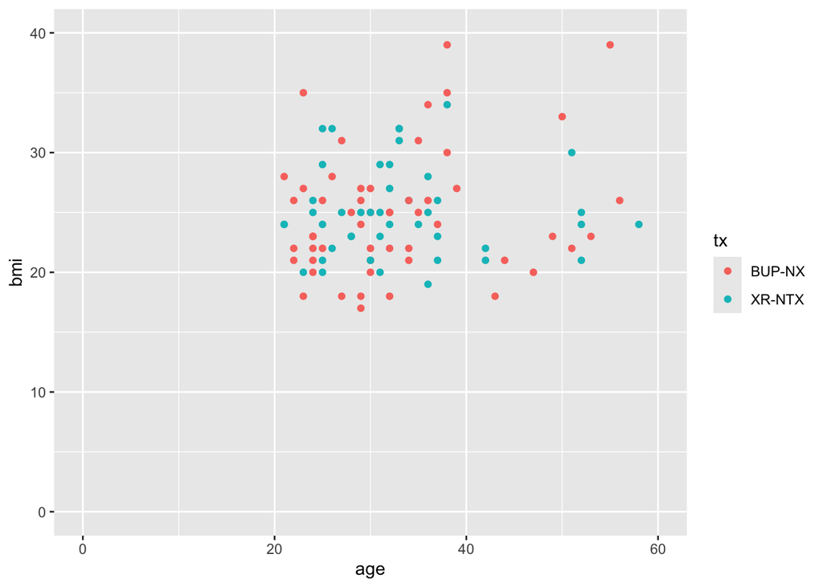

```r
ggplot(data = my_data, aes(x = age, y = bmi, color = tx)) +
  geom_point() +
  xlim(0,60) +
  ylim(0,40)
```

We can also add a title to our graph using `ggtitle()`:

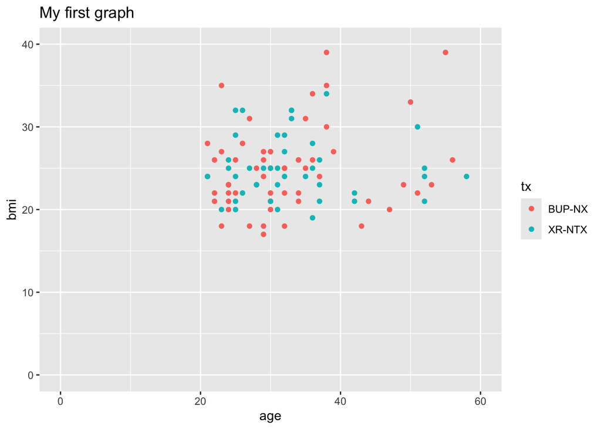

```r
ggplot(data = my_data, aes(x = age, y = bmi, color = tx)) +
  geom_point() +
  xlim(0,60) +
  ylim(0,40) +
  ggtitle("My first graph")
```

We can continue to add customizations using `+`. Learning all the customizations will take time. In the meantime, you can easily Google (or ask ChatGPT) about customizations. For example, you can look up “How do I change the x-axis label in ggplot?” in Google, and it will tell you how to change that configuration.

**Example**: Create a scatter plot with `educyrs` on the x-axis, `bmi` on the y-axis, and different colors for each `sex`.

```r
# write code here
```

## Line plot

For this example, we will first create a fake dataset saved to a variable `my_fake_data` which has the year, number of births, and number of deaths.

```r
# manually create a dataset with year, births, deaths
my_fake_data <- data.frame(year = c(2000, 2001, 2002, 2003, 2004, 2005),
                           births = c(240, 280, 290, 270, 500, 550),
                           deaths = c(500, 400, 300, 200, 120, 88))

my_fake_data
```

| year | births | deaths |
| --- | --- | --- |
| 2000 | 240 | 500 |
| 2001 | 280 | 400 |
| 2002 | 290 | 300 |
| 2003 | 270 | 200 |
| 2004 | 500 | 120 |
| 2005 | 550 | 88 |

Suppose that we wanted to graph a line graph with year on the x-axis and births on the y-axis. To do this, we can use the `geom_line()` geometric feature.

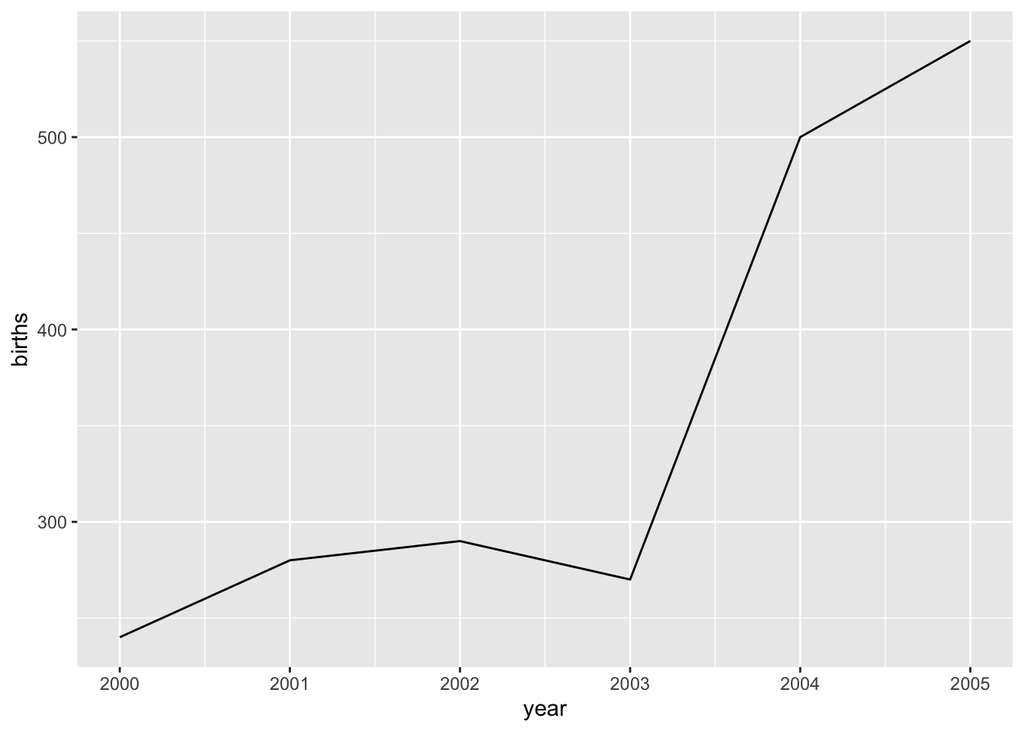

```r
ggplot(data = my_fake_data, aes(x = year, y = births)) +
  geom_line()
```

**Example**: Using `my_fake_data`, create a line plot with `year` on the x-axis, `deaths` on the y-axis. Use the `+ ylim()` customization to change the y-axis range from 0 to 600.

```r
# write code here
```

## Bar plots

We can also create bar plots using `+ geom_bar()`. For example, suppose that we wanted to graph the number in each treatment arm. We can write the following:

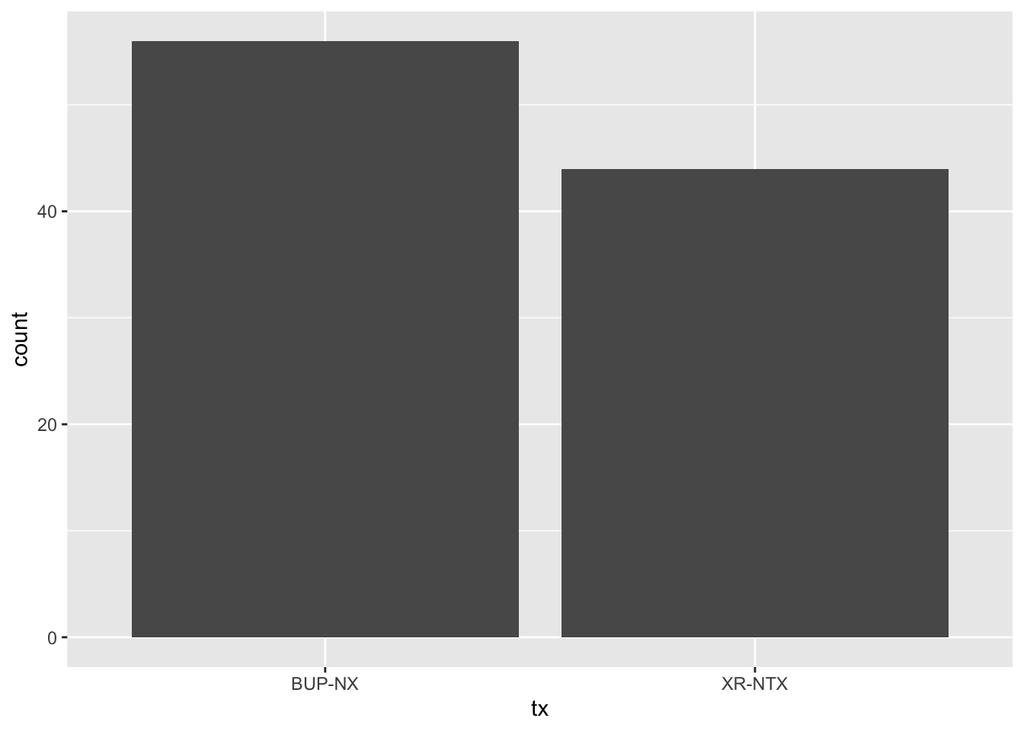

```r
ggplot(data = my_data, aes(x = tx)) +
  geom_bar()
```

Note that we don’t need a `y = y_var` specification in our `aes()` call. This is because `geom_bar()` by default counts the number in each category and uses that number as the height of the bar. So no need to specify the y-axis of this graph.

Now, suppose that we want to stratify the bars by sex. We can do this by adding a `fill` to our `aes()` call:

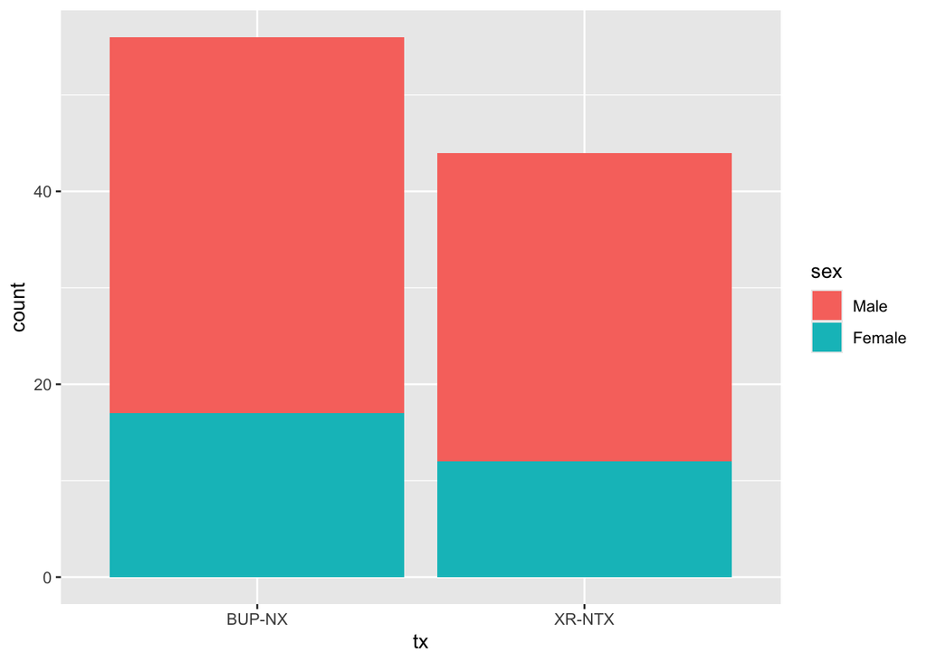

```r
ggplot(data = my_data, aes(x = tx, fill = sex)) +
  geom_bar()
```

We now have different colors indicating what proportion of each bar represent males and females.

**Example**: Create a bar plot showing the number of males and females (`sex`) in the dataset, with different colors for smokers and non-smokers (`smoke100`).

```r
# write code here
```

## Histograms

We can create histograms by `+ geom_histogram()`. For example, suppose that we want to create a histogram to look at the distribution of ages in our dataset.

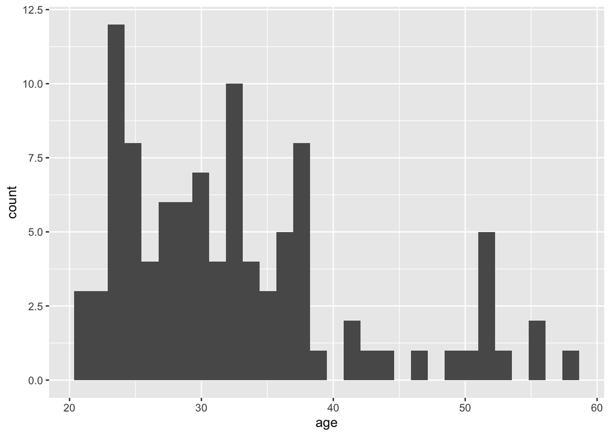

```r
ggplot(data = my_data, aes(x = age)) +
  geom_histogram()
```

We can customize the histogram by including additional arguments within the `geom_histogram()` function call. For example, to decrease to 5 bins (which increases the width of the bins), we can write the following:

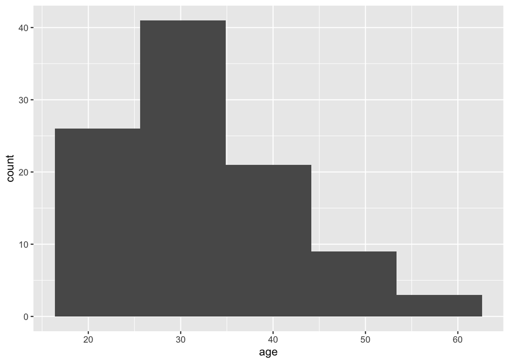

```r
ggplot(data = my_data, aes(x = age)) +
  geom_histogram(bins = 5)
```

**Example**: Create two separate histograms showing the distribution of the number of years of education for each treatment arm: `tx == "BUP-NX"` and `tx == "XR-NTX"`.

```r
# write code here
```

## Boxplots

Another common type of plot is a boxplot. In this type of plot, we can visually compare the distributions of a variable between different categories. For example, suppose that we wanted to compare the ages between the treatment arms. We can create a boxplot using `+ geom_boxplot()`:

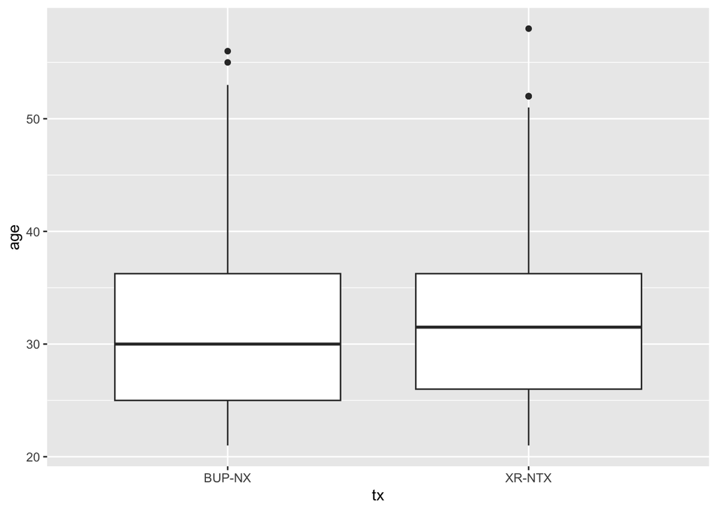

```r
ggplot(data = my_data, aes(x = tx, y = age)) +
  geom_boxplot()
```

**Example**: Create a boxplot comparing the distribution of BMIs (`bmi`) between males and females (`sex`).

```r
# write code here
```

# ChatGPT Demo

1. Read in your dataset and inspect it in R Studio.

```r
chatgpt_demo_df <- read.csv("chatgpt_demo.csv")

chatgpt_demo_df
```

| id | age | smoke | disease_score |
| --- | --- | --- | --- |
| 1 | 33 | 1 | 47.64758 |
| 2 | 37 | 0 | 44.67311 |
| 3 | 59 | 1 | 61.01461 |
| 4 | 41 | 0 | 44.07487 |
| 5 | 42 | 0 | 50.82840 |
| 6 | 61 | 0 | 69.91179 |
| 7 | 46 | 1 | 42.45790 |
| 8 | 25 | 0 | 47.11980 |
| 9 | 32 | 0 | 61.56675 |
| 10 | 35 | 1 | 76.37574 |

[output cut: 190 more lines]

2. Tell ChatGPT the structure of your dataset, including variable types and coding.

*I have a dataset which I’ve read into R into a dataframe variable called chatgpt_demo_df. It has four columns: (1) id: numeric id of the individual, (2) age: numeric age of the individual, (3) smoke: a binary variable coded as 0/1, and (4) disease_score: a score for disease severity. I want to ask you how to write R code to process and analyze this dataset.*

3. Be very specific with your asks. If you want to use familiar tools, ask it to use libraries that you are used to.

*I’d first like to process the dataset. I want to create a new dataframe, saved in the my_data_processed variable, which has age_month = age times 12, converts smoke to a factor with levels labelled “Non-Smoker” and “Smoker”, and remove all rows that have a missing age. I’d like to use the dplyr package. Can you help me write code to do this?*

```r
# paste ChatGPT's code below
```

*I’d like to run a linear regression, with disease severity as the outcome and smoking status and age as the predictors. I’d also like confidence intervals for the coefficients. Can you help me write code to do this?*

```r
# paste ChatGPT's code below
```

4. Check the code. Ask it to explain lines of code that you don’t understand. This is how you learn and ensure that it’s not making a mistake!

*I don’t understand the line of code filter(!is.na(age)). Can you explain it?*

5. If you are asking it to debug, paste both the code and the error message!

*I’m getting an error. Here is my code and error: model <- lm(disease_score | smoke + age, data = my_data_processed) Error in eval(mf, parent.frame()) : object ‘disease_score’ not found*

6. Interpret it yourself, but you can also use ChatGPT for help.

*Can you help me interpret this linear regression output?*

**Warning**: ChatGPT makes mistakes and is over-confident. Double check the code and make sure you understand what it does! Also, do not put any sensitive data into ChatGPT!